# Differential Reaction Activity Notebook

Scott Campit

# Summary

This notebook makes a reaction activity plot.

# 1. Load relevant libraries

```r
library(ggplot2)
library(tidyverse)
library(grid)
library(gridExtra)
library(scales)
```

# 2. Load datasets

The data consists of the log2 fold changes for each time transition (day 7/ day 0; day 14/ day7; day 21/ day14) plus their associated reaction identifiers and time transitions.

```r
filepath = "D:/Analysis/Immune/neutrophil_foldchange.csv"
df = read_csv(filepath, col_names=FALSE)
```

```r
id_path = "D:/Analysis/Immune/foldchange_ids.csv"
ids = read_csv(id_path, col_names=FALSE)
```

```r
label_path = "D:/Analysis/Immune/foldchange_labels.csv"
row_labels = read_csv(label_path, col_names=FALSE)
```

```r
colnames(df) = ids$X1
df$id = row_labels$X1
```

# 3. Create histograms

## A. Melt the dataframe

To create the histograms for each time transition fold change, I need to melt the dataframe and declare their `ids` as a factor.

```r
drsa = reshape2::melt(df, id.vars="id")
rm(list=c('df', 'ids', 'row_labels'))

drsa$id = factor(drsa$id, levels=c("Day 7 / Day 0",
                                 "Day 14 / Day 7",
                                 "Day 21 / Day 14"))
```

## B. visualize the histograms

The code block below will plot that. I chose a color palette that is color-blind friendly: https://venngage.com/blog/color-blind-friendly-palette/

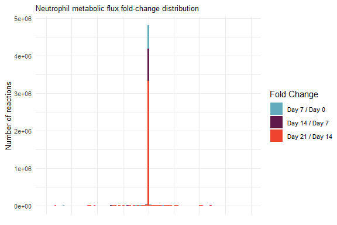

```r
# Create histogram of reaction distribution
p1 = ggplot(drsa, aes(x=value, fill=id)) +
  geom_histogram(bins=100, show.legend=TRUE) +
  #scale_y_log10() +
  theme_minimal() +
  xlim(-0.5, 0.5) +
  theme(plot.title = element_text(size=10),
              legend.text=element_text(size=8),
              axis.title.x=element_text(size=10),
              axis.title.y=element_text(size=10),
              axis.text.x=element_blank(),
              axis.text.y=element_text(size=8),
              legend.box="vertical",
              legend.margin=margin()) +
  labs(title="Neutrophil metabolic flux fold-change distribution",
       x=element_blank(),
       y="Number of reactions") +
  scale_fill_manual("Fold Change",
                    values=c("Day 7 / Day 0" = "#63ACBE",
                             "Day 14 / Day 7" = "#601A4A",
                             "Day 21 / Day 14" = "#EE442F"),
                    labels=c("Day 7 / Day 0",
                             "Day 14 / Day 7",
                             "Day 21 / Day 14"))
p1
```

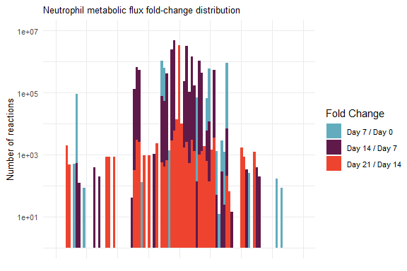

```r
p1 + scale_y_log10(limits=c(1, 1e7))
```

# 4. Create categorical scatter plots

To show where each reaction lies in the distribution, I created categorical scatterplots.

## A. Select a random subset of reactions to plot

However, the total number of reactions that can be plotted is ~ 5M, which takes up a lot of computation time, and looks horrific as a visualization. So, I sampled 2000 data points.

```r
# Create scatter plot distribution for each fold change + a little jitter
idx = sample(1:nrow(drsa), replace=FALSE)
idx = idx[1:2000]

tmp = data.frame(cbind(drsa$value[idx], as.character(drsa$id[idx])))
tmp$X1 = as.numeric(tmp$X1)
tmp$X2 = factor(tmp$X2, levels=c("Day 21 / Day 14",
                                 "Day 14 / Day 7",
                                 "Day 7 / Day 0"))
```

## B. Visualize the scatterplots

This code block creates the scatter plots

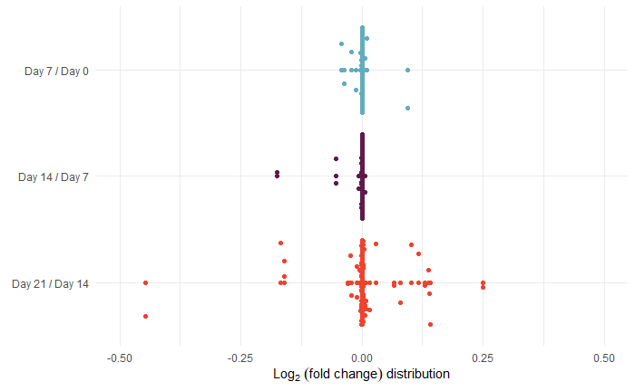

```r
p2 = ggplot(tmp, aes(x=X1, y=X2, color=X2)) +
     geom_point(show.legend=FALSE) +
     geom_jitter() +
     theme_minimal() +
     theme(legend.position="none") +
     xlim(-0.5, 0.5) +
     labs(x=expression(Log[2]~(fold~change)~distribution),
          y=element_blank()) +
     scale_color_manual(values=c("Day 7 / Day 0" = "#63ACBE",
                                 "Day 14 / Day 7" = "#601A4A",
                                 "Day 21 / Day 14" = "#EE442F"))
p2
```

# Conclusions and future directions

From here, you can copy and paste the plots together to create the full differential reaction activity (DRA) plot.

Some additional improvements could include:

- Automatic alignment of the plots
- Increased figure resolution
- Output of files